# Homework-Categorization-PartB

<h1 id="Homework---Categorization-and-Model-Comparison-Part-B-(35/105-points)">Homework - Categorization and Model Comparison Part B (35/105 points)</h1>

<p>PSY/COS 360, Computational Models of Cognition, Fall 2026.</p> <p>Credit for first version and for the categorization data: Prof. Todd Gureckis at New York University.</p>

<p style="margin-top: 0;">Parts of your code are checked by an automated grader. For the grader to work, please keep the following in mind as you complete the assignment:</p>

- **Do not rename this notebook file or any of the starter functions we provide.** The grader looks for them by name, so a renamed file or function will fail even if the code is correct.
- **Make sure the notebook runs from top to bottom without errors.** Before submitting, choose `Restart`, `Clear All Outputs`, and then `Run All` from the notebook menu. Confirm that every cell executes in order and produces the expected output.
- **Do NOT clear the output when submitting.** Submit the notebook with the output of each cell. The grader may use these values.

<hr />

```python
import seaborn as sns
import pandas as pd
import math
from scipy.optimize import fmin
from scipy.special import comb  # gets the combinations function
from exemplarproto import *  # this grabs much of the code from Part A of the homework
# note that , Part B runs the frozen copy in exemplarproto.py, not your edited Part A cells
```

<h2 id="Fitting-the-models-using-maximum-likelihood">Fitting the models using maximum likelihood</h2>

<p>RMSE is not always an ideal mechanism for fitting models. One reason is that it is insensitive to the number of observations that define each data point. For example, remember in our experiment that participants saw the prototype item four times at test. In contrast, there were 20 different "new" patterns. This means there are five times as many trials contributing to the "new" bar in this graph as for the prototype patterns. Since RMSE measures the raw deviation of the average model predictions from those of the model it doesn't take into account these issues. Thus, we would like to also evaluate these two models using maximum likelihood.</p> <p>The key to this is going to be the provided function below which computes the likelihood of a particular set of data under a binomial probability model. Again, this uses the Pandas library, with a [short introduction here](https://pandas.pydata.org/docs/user_guide/10min.html) and an explanation of the [.groupby](https://pandas.pydata.org/docs/user_guide/groupby.html) routine.</p>

```python
################################
# computeLogLikelihood
# N = number of observations
# S = number of "successes" (i.e., endorsements)
# p = predicted probability of successes by the model
################################
def computeLogLikelihood(N, S, p):
    p = p if p > 0.0 else 0.0+1e-10
    p = p if p < 1.0 else 1.0-1e-10
    try:
        result = math.log(comb(N, S)) + (S*math.log(p) + (N-S)*math.log(1.0-p)) # log binomial likelihood
    except:
        print(N, S, p)  # this shouldn't happen but just in case
        result = float('-inf')
    return result


def pandas_ll(row):
    return computeLogLikelihood(row['Total'], row['N_Yes'], row['Probability of Endorsement'])
```

<p>A short explanation may be in order: the models predictions take the form of probabilities of endorsement for each of the prototype, low, high, random, and old items. If you find out that people endorse the prototype on 2 out of 2 trials how likely is this outcome given that the model (for a particular set of parameters ) predicts an endorsement of p=0.8? Three numbers are required to do this for each data point N, the number of trials/presentations within the stimulus class, S the number of successes observed (S<=N), and p the predicted probability. Then you can turn the crank on the above `computeLogLikelihood()` function which returns the probability that you would get $S$ successes in $N$ trials if the true probability was $p$ (make sure you understand what is happening in `computeLogLikelihood`). You can sum these log likelihoods for each stimulus class (prototype, low, high, random, old) to compute a total log(likelihood) of the data for any given model with any set of parameters. For this homework will we focus on fitting the group data rather than to individuals.</p>

<p>To get the data formatted into an appropriate shape for fitting likelihoods we provide a function `get_human_results_ll()` which returns a Pandas data frame containing the number of times a pattern of a particular type was endorsed and the number of times it was presented for each subject.</p>

```python
human_res=get_human_results_ll()
human_res
```

| ./data/8.dat | cat | Prototype | 4 | 4 |
| --- | --- | --- | --- | --- |
| ./data/8.dat | cat | Low | 4 | 4 |
| ./data/8.dat | cat | High | 10 | 10 |
| ./data/8.dat | cat | Random | 15 | 20 |
| ./data/8.dat | cat | Old | 20 | 20 |
| ... | ... | ... | ... | ... |
| ./data/7.dat | rec | Prototype | 3 | 4 |
| ./data/7.dat | rec | Low | 4 | 4 |
| ./data/7.dat | rec | High | 8 | 10 |
| ./data/7.dat | rec | Random | 0 | 20 |
| ./data/7.dat | rec | Old | 19 | 20 |

<p>70 rows × 5 columns</p>

<p>This reorganizes the data per condition.</p>

```python
human_data=human_res.groupby(['Condition','Stimulus Type']).sum(numeric_only=True).reset_index()
human_data
```

| cat | High | 49 | 70 |
| --- | --- | --- | --- |
| cat | Low | 26 | 28 |
| cat | Old | 110 | 140 |
| cat | Prototype | 25 | 28 |
| cat | Random | 37 | 140 |
| rec | High | 20 | 70 |
| rec | Low | 16 | 28 |
| rec | Old | 89 | 140 |
| rec | Prototype | 18 | 28 |
| rec | Random | 7 | 140 |

<p>Finally these function allow us to compute the negative log likelihood of the data given the model.</p>

```python
def fit_exemplar_model_nll(params, human_results):
    [c_cat, k_cat, c_rec, k_rec] = params
    k_cat = k_cat if k_cat > 0.0 else 0.0
    k_rec = k_rec if k_rec > 0.0 else 0.0
    predictions = get_exemplar_results(c_cat, k_cat, c_rec, k_rec)
    model = predictions.groupby(
        ['Condition', 'Stimulus Type'], as_index=False).mean(numeric_only=True)
    fitted_data = pd.merge(model, human_results)
    return -1.0*fitted_data.apply(pandas_ll, axis=1).sum()


def fit_prototype_model_nll(params, human_results):
    [c_cat, k_cat, c_rec, k_rec] = params
    k_cat = k_cat if k_cat > 0.0 else 0.0
    k_rec = k_rec if k_rec > 0.0 else 0.0
    predictions = get_prototype_results(c_cat, k_cat, c_rec, k_rec)
    model = predictions.groupby(
        ['Condition', 'Stimulus Type'], as_index=False).mean(numeric_only=True)
    fitted_data = pd.merge(model, human_results)
    return -1.0*fitted_data.apply(pandas_ll, axis=1).sum()
```

<h3> Problem 6 (20 points) </h3><br> The cell blocks below allow you to fit the exemplare model and the prototype model to the dataset we considered in Part A of the homework. Make sure you understand and follow the code provided above and in the provided library (exemplarproto.py). Next, try altering the parameters to minimize the negative log likelihood score using the `fmin` approach form Part 1. When you think you have found the best fit parameters for both the exemplar and prototype models report your final parameter values along with the plot of the resulting model predictions. In a markdown cell describe which model you believe fits better. Is this conclusion the same or different from what you considered with RMSE? If the fit looks different, why?

```python
initial_params = [1.0, 1.0, 1.0, 1.0]
param_opt_exemplar, log_exemplar, *_ = fmin(func=fit_exemplar_model_nll, x0=initial_params, args=(human_data,), full_output=True)
param_opt_prototype, log_prototype, *_ = fmin(func=fit_prototype_model_nll, x0=initial_params, args=(human_data,), full_output=True)
print('The Log Likelihood for the exemplar model is: ', log_exemplar)
print('The Log Likelihood for the prototype model is: ', log_prototype)
```

```
Optimization terminated successfully.
         Current function value: 28.268922
         Iterations: 118
         Function evaluations: 203
Optimization terminated successfully.
         Current function value: 32.246756
         Iterations: 244
         Function evaluations: 408
The Log Likelihood for the exemplar model is:  28.268922163068854
The Log Likelihood for the prototype model is:  32.246756110364004
```

```python
print('The params for the exemplar model is: ', param_opt_exemplar)
print('The params for the prototype model is: ', param_opt_prototype)
```

```
The params for the exemplar model is:  [1.48765773 0.35962075 1.93039443 0.78403173]
The params for the prototype model is:  [1.58819778 0.03164482 1.87908101 0.08401762]
```

<p>**ANSWER HERE: For the exemplar model, I got a minimized negative log likelihood value of 28.268922163068854 corresponding to the parameter values of c_cat = 1.48765773, k_cat = 0.35962075, c_rec = 1.93039443, and k_rec = 0.78403173. For the prototype model, I got a minimized negative log likelihood value of 32.246756110364004 corresponding to the parameter values of c_cat = 1.58819778, k_cat = 0.03164482, c_rec = 1.87908101, and k_rec = 0.08401762. The plots for these parameters are displayed below. I believe the exemplar model fits better because it has a smaller minimized negative log likelihood value. This conclusion is the same as when minimizing RMSE, but I got different parameter values. This is likely because RMSE and negative log likelihood are different optimization metrics so they are unlikely to be minimized under the same conditions.**</p>

<p>**Exemplar model**</p>

```
The negative log score is 28.268922163070332
```

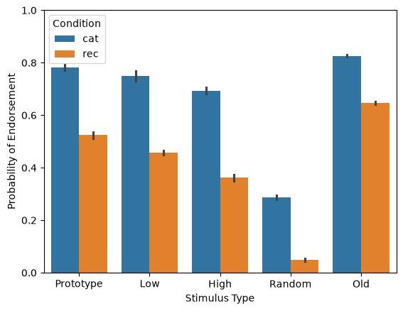

```python
human = human_res.groupby(['Condition', 'Stimulus Type'], as_index=False).sum(numeric_only=True)

params = [1.48765773, 0.35962075, 1.93039443, 0.78403173]
nllfit = fit_exemplar_model_nll(params, human)
print(f'The negative log score is {nllfit}')

# now plot the data
c_cat, k_cat, c_rec, k_rec = params
res = get_exemplar_results(c_cat, k_cat, c_rec, k_rec)
ax = sns.barplot(x="Stimulus Type", y="Probability of Endorsement",
            hue="Condition", data=res)
ax.set_ylim(0, 1.0);
```

<p>**Prototype Model**</p>

```
The negative log score is 32.2467561104539
```

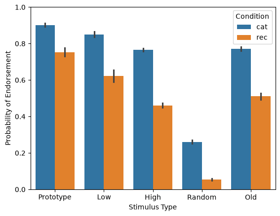

```python
human = human_res.groupby(['Condition', 'Stimulus Type'], as_index=False).sum(numeric_only=True)

params = [1.58819778, 0.03164482, 1.87908101, 0.08401762]
nllfit = fit_prototype_model_nll(params, human)
print(f'The negative log score is {nllfit}')

# now plot the data
c_cat, k_cat, c_rec, k_rec = params
res = get_prototype_results(c_cat, k_cat, c_rec, k_rec)
ax = sns.barplot(x="Stimulus Type", y="Probability of Endorsement",
            hue="Condition", data=res)
ax.set_ylim(0, 1.0);
```

<p>**Human data again for reference**</p>

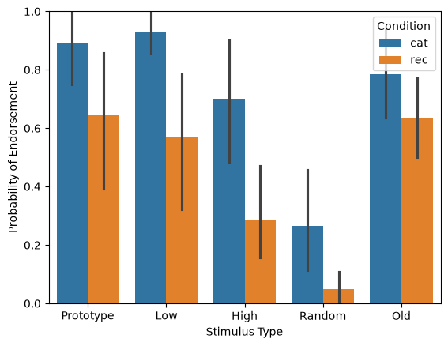

```python
ax = sns.barplot(x="Stimulus Type", y="Probability of Endorsement",
            hue="Condition", data=get_human_results())
ax.set_ylim(0, 1.0);
```

<h3> Problem 7 (10 points) </h3><br> A famous saying is the "All models are wrong, but some are useful" (George Box). Do you think the exemplar or prototype model provides the best account of the data? Refer to particular patterns in the data that you believe the different models do a better job with.

<p>**ANSWER HERE: Based on the performances for different evaluation functions, the exemplar model seems to perform the better account of the data, but both the exemplar and prototype models perform pretty well and explain different phenomena in the human data better. The exemplar model predicts the high endorsement rate of old stimuli in the recognition condition very well and it predicts the similar endorsement rates of prototype and old stimuli in the categorization condition. However, in the human data for the categorization condition, prototype stimuli has higher (but similar) endorsement rates, which the exemplar model doesn't predict. The prototype model does predict the higher prototype stimuli rate of endorsement in the categorization task. It doesn't predict the high performance of old stimuli in the recognition task. Neither model predicts the fact that low distortion stimuli had the highest probability of endorsement in the categorization task.**</p>

<h3> Problem 8 (5 points) </h3><br> <p>Thinking about how these models work explain why both the exemplar and prototype models have relatively high endorsement for the prototype item even though it was never presented during the training phase. In addition, explain in your own words why the models are able to explain the high endorsement rates for the old items.</p>

<p>**ANSWER HERE: The exemplar model has relatively high endorsement for the prototype item because that item is likely to be similar to multiple of the exemplars and thus be more likely to be in the category. The prototype model has relatively high endorsement for the prototype item because the model assumes that a person learns a prototype of the category without having to see that prototype, which means it should have high endorsement probability. The exemplar model was able to explain high endorsement rates for old items because the model assumes that all examplars (old items) are stored in memory, so these would have a higher endorsement probability. The prototype model is able to explain relatively high endorsement rates for old items because the old items are used to form the prototype/mental representation and are thus likely to be similar to the prototype representation which would give them a higher probability of endorsement.**</p>